# PSTAT 100: Midterm Review

Examples, practice, and solutions

Author

Yuting Ma

## 1. Start with the question

A researcher asks: **“How did annual PM2.5 concentrations change across cities between 2023 and 2024?”**

Before making a plot:

1. What is a natural observational unit?
2. Name one thing you should check about the data.

**TipSolution 1**

1. **One city in one year**: a city–year observation.
2. Examples: units of measurement, missing values, duplicate city–year records, which cities were included, or whether measurements were collected consistently across years.

## 2. Tidy data and transformations

These are **made-up data**. PM2.5 is measured in micrograms per cubic meter.

```r
air_wide <- tibble(
  city = c("Bay", "Hill", "Mesa"),
  `2023` = c(8, 12, 10),
  `2024` = c(6, NA, 8)
)

air_wide
```

```
# A tibble: 3 × 3
  city  `2023` `2024`
  <chr>  <dbl>  <dbl>
1 Bay        8      6
2 Hill      12     NA
3 Mesa      10      8
```

### A. Worked example: make one row per city–year

For our question, the column names `2023` and `2024` are values of a **year** variable. Move them into a column:

```r
air_long <- air_wide |>
  pivot_longer(
    cols = c(`2023`, `2024`),
    names_to = "year",
    values_to = "pm25"
  ) |>
  mutate(year = as.integer(year))

air_long
```

```
# A tibble: 6 × 3
  city   year  pm25
  <chr> <int> <dbl>
1 Bay    2023     8
2 Bay    2024     6
3 Hill   2023    12
4 Hill   2024    NA
5 Mesa   2023    10
6 Mesa   2024     8
```

How many rows and columns does `air_long` have? Does the missing measurement disappear?

**TipSolution 2A**

**6 rows and 3 columns:** `city`, `year`, and `pm25`. The Hill–2024 row remains, with `pm25 = NA`; `pivot_longer()` retains missing values by default.

Each row is one city–year, and each column is one variable. Converting `year` to an integer makes it numeric instead of the character values produced from the original column names.

Tidy does not always mean “make everything longer.” The layout depends on the observational unit and variables.

### B. Your turn: predict the output

Read the pipeline before running it:

```r
air_long |>
  group_by(city) |>
  summarise(
    mean_pm25 = mean(pm25, na.rm = TRUE),
    n_observed = sum(!is.na(pm25)),
    .groups = "drop"
  )
```

1. What are the mean and number of observed measurements for each city?
2. What happens to Hill’s mean if we remove `na.rm = TRUE`?
3. If we used `n()` instead of `sum(!is.na(pm25))`, what would it count?

**TipSolution 2B**

| city | mean_pm25 | n_observed |
| --- | --- | --- |
| Bay | 7 | 2 |
| Hill | 12 | 1 |
| Mesa | 9 | 2 |

```r
city_summary <- air_long |>
  group_by(city) |>
  summarise(
    mean_pm25 = mean(pm25, na.rm = TRUE),
    n_observed = sum(!is.na(pm25)),
    .groups = "drop"
  )
```

Without `na.rm = TRUE`, Hill’s mean is **`NA`**. `n()` counts **all rows** in each group, so it would return 2 for every city, including Hill.

Ignoring an `NA` lets us compute a mean from available values. It does **not** establish that the available values represent the missing ones. Hill’s mean uses only 2023, while the other means use both years.

### C. Quick code check

Which expression keeps only 2024 observations with PM2.5 at most 8?

```r
# A
air_long |> filter(year == 2024, pm25 <= 8)

# B
air_long |> select(year == 2024, pm25 <= 8)
```

**TipSolution 2C**

**A.** `filter()` selects rows using conditions; `select()` selects columns.

The retained rows are **Bay–2024 (6)** and **Mesa–2024 (8)**. Hill–2024 is dropped because its condition evaluates to `NA`, and `filter()` keeps only rows whose conditions are `TRUE`.

Use `is.na(pm25)` to find missing values; `pm25 == NA` does not test missingness correctly.

## 3. Sampling: what are we estimating?

### A. Population, frame, and sample

We want the average nightly sleep duration of **all UCSB undergraduates**. We obtain a list of students living in university residence halls, randomly select 100 names, and successfully measure all 100 students’ sleep.

Identify the **target population**, **sampling frame**, and **sample**. Can we confidently generalize to all undergraduates just because the selection was random?

**TipSolution 3A**

- **Target population:** all UCSB undergraduates.
- **Sampling frame:** students on the residence-hall list.
- **Sample:** the 100 selected students whose sleep we measured.

The frame excludes undergraduates living elsewhere. Random selection from this frame does not remove that coverage problem. If residence-hall students sleep differently, the sample mean may be biased for the target population mean.

Sampling 1,000 students from the same list would not solve the coverage problem. More data can reduce random variation while leaving the coverage problem.

### B. Observations versus sample means

Suppose we repeatedly draw independent samples **with replacement** from a population with mean $\mu = 7$ hours and standard deviation $\sigma = 2$ hours. Each sample contains $n = 100$ observations, and we compute its mean.

1. Is the sampling distribution a distribution of individual sleep durations or of sample means?
2. What are its mean and standard deviation?
3. If we increase the sample size to 400, what happens to that standard deviation?

**TipSolution 3B**

1. It is the distribution of **sample means across repeated samples**.
2. For independent draws,

$$E[\bar Y] = \mu = 7,
\qquad
\operatorname{SD}(\bar Y) = \frac{\sigma}{\sqrt n}
= \frac{2}{\sqrt{100}} = 0.2\text{ hours}.$$

3. With $n = 400$, it becomes $2/\sqrt{400} = 0.1$ hours. Quadrupling the sample size halves the standard error.

The CLT says the sampling distribution of the mean is approximately normal for sufficiently large samples under suitable conditions. It does **not** say the individual sleep durations become normal.

## 4. Visualization: read and fix the plot

We want to compare the two annual measurements for each city.

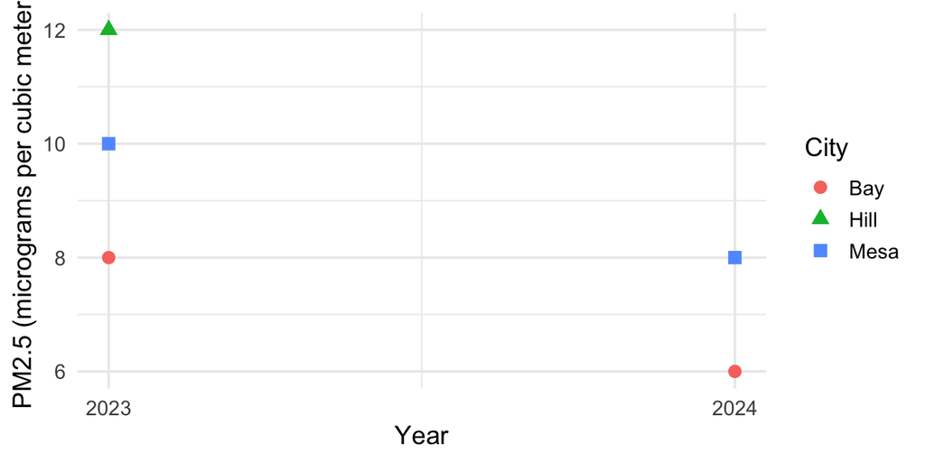

```r
air_long |>
  filter(!is.na(pm25)) |>
  ggplot(aes(x = year, y = pm25, color = city, shape = city)) +
  geom_point(size = 3) +
  scale_x_continuous(breaks = c(2023, 2024)) +
  labs(x = "Year", y = "PM2.5 (micrograms per cubic meter)",
       color = "City", shape = "City")
```

1. Which variables map to x, y, color, and shape?
2. Why might mapping both color and shape to city be useful?
3. A student wants every point blue and writes the following. How should they fix it?

```r
ggplot(air_long, aes(x = year, y = pm25)) +
  geom_point(aes(color = "blue"))
```

**TipSolution 4**

1. `year` maps to x, `pm25` to y, and `city` to both color and shape.
2. This is **redundant coding**: shape provides another way to identify cities when colors are hard to distinguish.
3. Set a fixed color **outside** `aes()`:

```r
ggplot(air_long, aes(x = year, y = pm25)) +
  geom_point(color = "blue", na.rm = TRUE)
```

Inside `aes()`, `"blue"` is treated as a categorical value to map through a color scale; it does not directly set the color blue.

**Interpretation:** Bay and Mesa have lower recorded PM2.5 in 2024. We cannot determine Hill’s change because its 2024 measurement is missing. These three fictional cities do not establish a trend for all cities.

## 5. Exit check

Give a one-sentence reason for each answer:

1. True or false: increasing sample size always eliminates bias.
2. Which operation usually gives one summary row per group: `mutate()` or `summarise()`?
3. True or false: the height of a density curve at a point is the probability of observing exactly that value.

**TipExit-check solutions**

1. **False.** A larger sample does not automatically fix an unrepresentative frame or biased selection.
2. **`summarise()`.** It aggregates within groups. `mutate()` adds or changes columns while retaining the rows.
3. **False.** For a continuous distribution, probabilities are areas over intervals; the probability at a single exact value is zero.

## Additional practice

### Joining tables

Table A has one row each for Bay and Hill. Table B has one row each for Hill and Mesa. Join on `city`, with no duplicate keys.

Which cities appear in an `inner_join(A, B)`, a `left_join(A, B)`, and a `full_join(A, B)`?

**TipOptional solution: joins**

| Join | Cities in the result |
| --- | --- |
| `inner_join(A, B, by = "city")` | Hill |
| `left_join(A, B, by = "city")` | Bay, Hill |
| `full_join(A, B, by = "city")` | Bay, Hill, Mesa |

Unmatched values from the other table become `NA` in left and full joins. Choosing a join depends on which observations the analysis should retain.

### Inverse probability weighting

Two observed units have values 4 and 10, with known positive inclusion probabilities 0.25 and 0.50. Compute the normalized inverse-probability weighted mean.

**TipOptional solution: weighting**

The weights are $1/0.25=4$ and $1/0.50=2$:

$$\hat\mu_{\mathrm{IPW}} = \frac{4\times4+2\times10}{4+2} = 6.$$

The less likely unit receives more weight. The ordinary mean would be 7. Weighting can adjust for unequal inclusion when probabilities are appropriate, but it does not guarantee an exact or unbiased estimate in every finite sample. Weighting cannot account for people who have no chance of entering your sample